# W3cubDocs

/Kotlin

# Get started with Kotlin/Native using IntelliJ IDEA

| **Last Updated** | 20 August 2020 |
| --- | --- |

This tutorial demonstrates how to use IntelliJ IDEA for creating a Kotlin/Native application.

To get started, install the latest version of [IntelliJ IDEA](http://www.jetbrains.com/idea/download/index.html). The tutorial is applicable to both IntelliJ IDEA Community Edition and the Ultimate Edition.

## Create a new Kotlin/Native project in IntelliJ IDEA

1. In IntelliJ IDEA, select **File** | **New** | **Project**.
2. In the panel on the left, select **Kotlin**.
3. Enter a project name, select **Native Application** as the project template, and click **Next**.

[figure not shown]

   By default, your project will use Gradle with Kotlin DSL as the build system.

   > Kotlin/Native doesn't support Maven and IntelliJ IDEA native builder.
4. Accept the default configuration on the next screen and click **Finish**.

[figure not shown]

Your project will open. By default, the wizard creates the necessary `main.kt` file with code that prints "Hello, Kotlin/Native!" to the standard output.

The `build.gradle.kts` file contains the project settings. Read more about these settings in the Kotlin Multiplatform Gradle DSL reference.

## Run the application

Start the application by clicking **Run** next to the run configuration at the top of the screen.

[figure not shown]

IntelliJ IDEA opens the **Run** tab and shows the output:

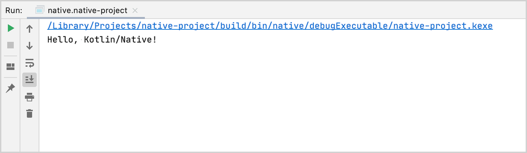

## Update the application

### Count the letters in your name

1. Open the file `main.kt` in `src/<your_app_name>Main/kotlin`.

   The `src` directory contains the Kotlin source files and resources. The file `main.kt` includes sample code that prints "Hello, Kotlin/Native!" using the `println()` function.
2. Add code to read the input. Use the `readLine()` function to read the input value and assign it to the `name` variable.

   ```
   fun main() {
       // Read the input value.
       println("Hello, enter your name:")
       val name = readLine()
   }
   ```

3. Eliminate the whitespaces and count the letters:
   - Check that the provided name is not `null` with the safe call operator `?.`.
   - Use the `replace()` function to remove the empty spaces in the name.
   - Use the scope function `let` to run the function within the object context.
   - Use a string template to insert your name length into the string by adding a dollar sign `$` and enclosing it in curly braces – `${it.length}`. `it` is the default name of a lambda parameter.

   ```
   fun main() {
       // Read the input value.
       println("Hello, enter your name:")
       val name = readLine()
       // Count the letters in the name.
       name?.replace(" ", "")?.let {
           println("Your name contains ${it.length} letters")
       }
   }
   ```

4. Report a null value using the `error()` function after the Elvis operator `?:`.

   ```
   fun main() {
       // Read the input value.
       println("Hello, enter your name:")
       val name = readLine()
       // Count the letters in the name.
       name?.replace(" ", "")?.let {
           println("Your name contains ${it.length} letters")
       } ?: error("Error while reading input from the terminal: the value can't be null.")
   }
   ```

5. Save the changes and run the application.

   IntelliJ IDEA opens the **Run** tab and shows the output.
6. Enter your name and enjoy the result:

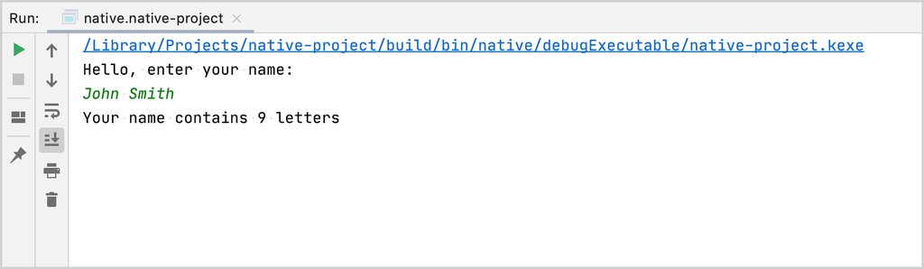

### Count the unique letters in your name

1. Open the file `main.kt` in `src/<your_app_name>Main/kotlin`.
2. Declare the new extension function `countDistinctCharacters()` for `String`:
   - Convert the name to lowercase using the `toLowerCase()` function.
   - Convert the input string to a list of characters using the `toList()` function.
   - Select only the distinct characters in your name using the `distinct()` function.
   - Count the distinct characters using the `count()` function.

   ```
   fun String.countDistinctCharacters() = toLowerCase().toList().distinct().count()
   ```

3. Use the `countDistinctCharacters()` function to count the unique letters in your name.

   ```
   fun String.countDistinctCharacters() = toLowerCase().toList().distinct().count()

   fun main() {
       // Read the input value.
       println("Hello, enter your name:")
       val name = readLine()
       // Count the letters in the name.
       name?.replace(" ", "")?.let {
           println("Your name contains ${it.length} letters")
           // Print the number of unique letters.
           println("Your name contains ${it.countDistinctCharacters()} unique letters")
       } ?: error("Error while reading input from the terminal: the value can't be null.")
   }
   ```

4. Save the changes and run the application.

   IntelliJ IDEA opens the **Run** tab and shows the output.
5. Enter your name and enjoy the result:

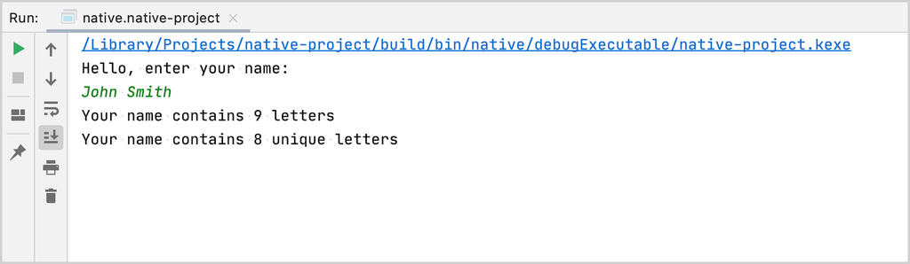

## What's next?

Once you have created your first application, you can go to Kotlin hands-on labs and complete long-form tutorials on Kotlin/Native.

For Kotlin/Native, the following hands-on labs are currently available:

- [Learn about the concurrency model in Kotlin/Native](https://play.kotlinlang.org/hands-on/Kotlin%20Native%20Concurrency/00_Introduction) shows you how to build a command-line application and work with states in a multi-threaded environment.
- [Creating an HTTP Client in Kotlin/Native](https://play.kotlinlang.org/hands-on/Introduction%20to%20Kotlin%20Native/01_Introduction) explains how to create a native HTTP client and interoperate with C libraries.

© 2010–2020 JetBrains s.r.o. and Kotlin Programming Language contributors  
Licensed under the Apache License, Version 2.0.  
https://kotlinlang.org/docs/tutorials/native/using-intellij-idea.html